# Data Tool Prototype

# State of the Gap: Homeownership Disparities by Race and Ethnicity

Large gaps in homeownership rates and wealth persist between racial/ethnic groups as households of color face significant disadvantages relative to white households in both attaining and sustaining homeownership. The Black-white homeownership rate gap is almost as wide now as it was in 1960, when the Fair Housing Act had not yet been passed and housing discrimination was still legal (McCargo & Choi 2020). The persistence of these gaps, long after overtly discriminatory practices have been barred, is evidence of the systemic barriers that still prevent people of color from receiving credit, or receiving it on terms as favorable as white borrowers.

In the mid-20th century, the Federal Home Owner’s Loan Corporation (HOLC), the precursor to the Federal Housing Agency, explicitly and systematically denied mortgage lending to communities that were predominantly non-white through a process known as redlining (Rothstein, 2017). Racially restrictive covenants in the early 20th century prohibited African Americans, Latinos, Asians and other non-white households from purchasing or owning homes in certain, often affluent and white, communities (Turner and Greene). People of color had less access to the 30-year mortgages, revolving credit, and Federal Deposit Insurance Corporation–backed bank accounts that underpinned the growing middle class. In their absence, costlier, riskier, and less regulated alternatives filled the void, using business models that often trapped people in cycles of debt and limited their ability to build a traditional credit history (Perry, Choi, and Reynolds blog). For example, Black homebuyers disproportionately utilized land sale contracts to purchase housing, which lack the protections of mortgage financing in default scenarios. Between 1950-1970, in Chicago alone it is estimated land sale contracts stripped Black households of between 3.2 and 4.0 billion in wealth (George et al. 2019, Brown 2016).

More recently, driven by targeted lending of predatory products to borrowers of color, the great recession had a greater negative economic impact on homeowners of color. During the foreclosure crisis, Black and Hispanic households were 76 and 71 percent more likely to be foreclosed on than white owners, respectively (Bocian, Li and Ernst 2010, Neal and McCargo 2020, Choi et al. 2019). Negative shocks like recessions and natural disasters still disproportionally impact homeowners of color, widening gaps and setting vulnerable households further back. Prohibitively tight credit in the aftermath of the 2008 recession reduced lending to Black and Hispanic borrowers by 76 and 78 percent from 2005 to 2012 (Goodman, Zhu and George 2014).

The staple legislation aimed at remedying historic lending discrimination, the Community Reinvestment Act (CRA), has fallen short of creating equal access to housing credit. Majority-minority communities receive less lending as a share of households than white neighborhoods, and research demonstrates that low-to-moderate designation that guides CRA activity is not a strong proxy for race (Goodman et al. 2022).

## Homeownership Rates

### Homeownership Rate by Race, National 1960 - 2021

Large gaps in homeownership rates and wealth persis between racial/ethnic groups as households of color face significant disadvantages relative to white households in both attaining and sustaining homeownership. The Black-white homeownership gap is almost as wide now as it was in 1960, before the Fair Housing Act was passed and when housing discrimination was still legal. The persistence of this gap suggests that systemic racism is maintaing the same outcomes as the overtly racist practices of the past.

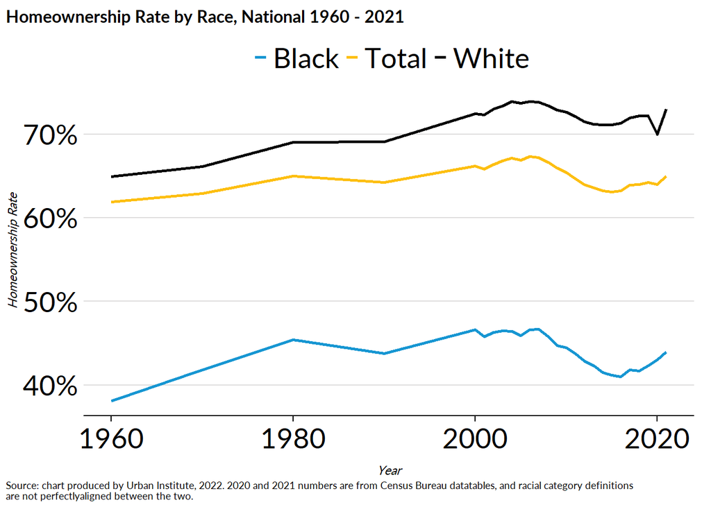

### Homeownership Rate by Race, MSA

The Black-white homeownership gap persists in most metro areas. In the Atlanta - Sandy Springs - Alpharetta MSA, the homeownership rate among white households is 70%, compared to 48% among Black households.

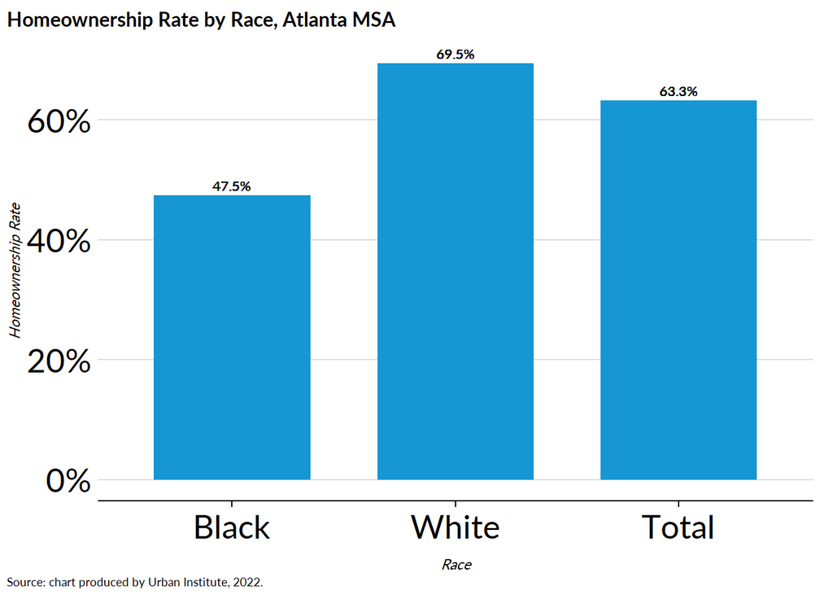

### Distribution of Households and Primary-Residence Wealth by Race, National

Despite accounting for 16% of all households, Black households own only 6% of primary residence wealth. Conversely, white households account for 63% of households but 75% of primary residence wealth.

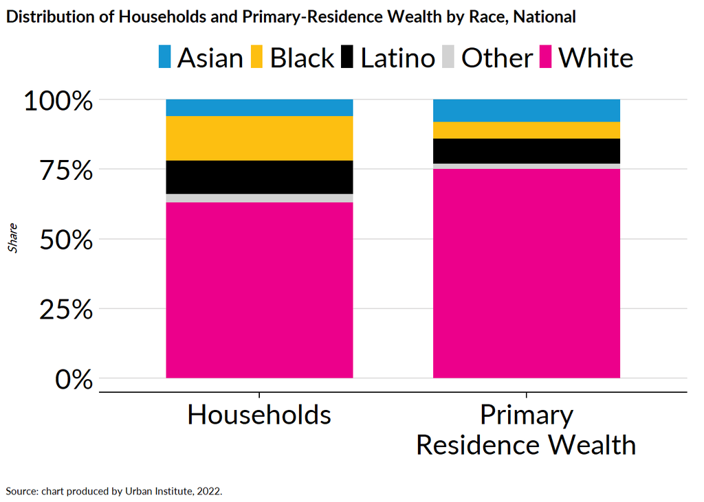

### Distribution of Households and Primary-Residence Wealth by Race, MSA

In Atlanta, Black households account for 44% of all households, but they own only 17% of primary residence wealth. White households make up 45% of households and own 72% of primary residence wealth.

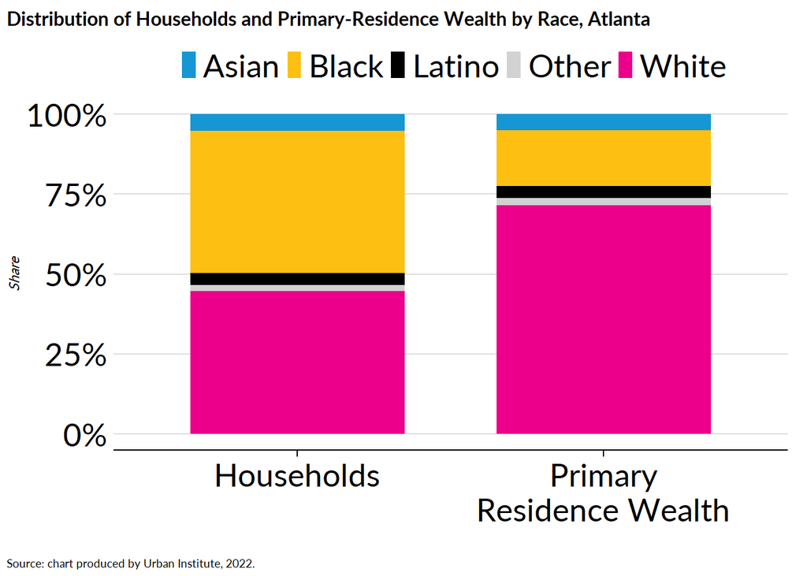

## Denial Rates

### Denial Rate by Race: Purchase Mortgages, National

The national denial rate for purchase mortgage applications is 25% for Black applicants, compared to 11% for white applicants.

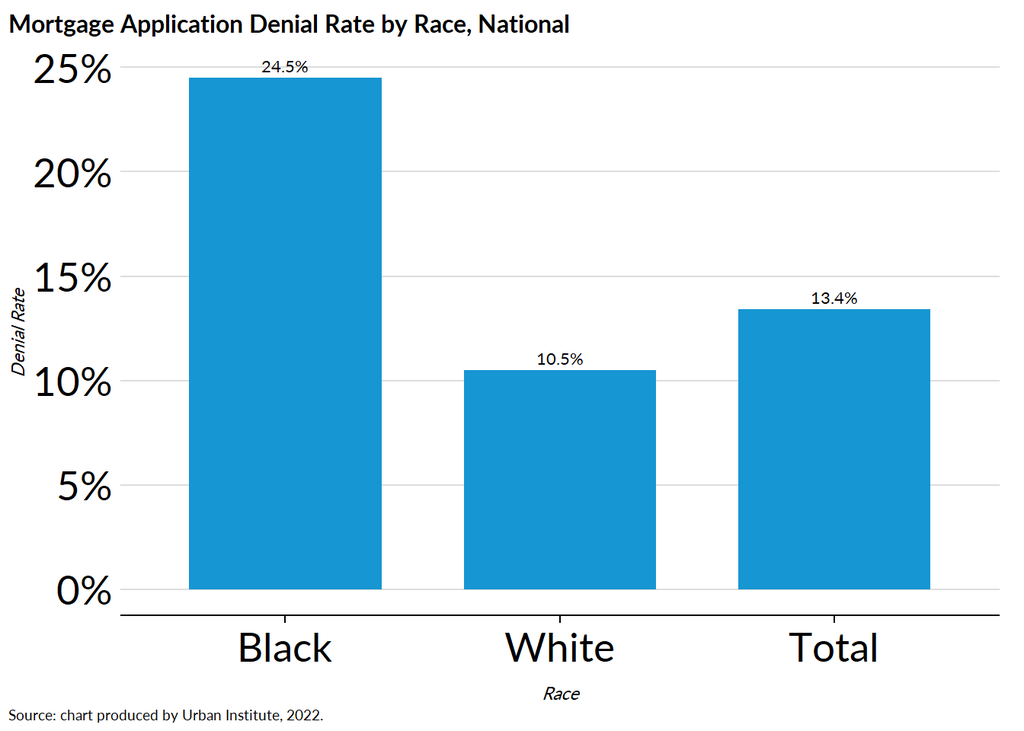

### Denial Rate by Race: Purchase Mortgages, MSA

In the Atlanta - Sandy Springs - Alpharetta MSA, the denial rate for Black applicants is 16%, comapred to 7% for white applicants.

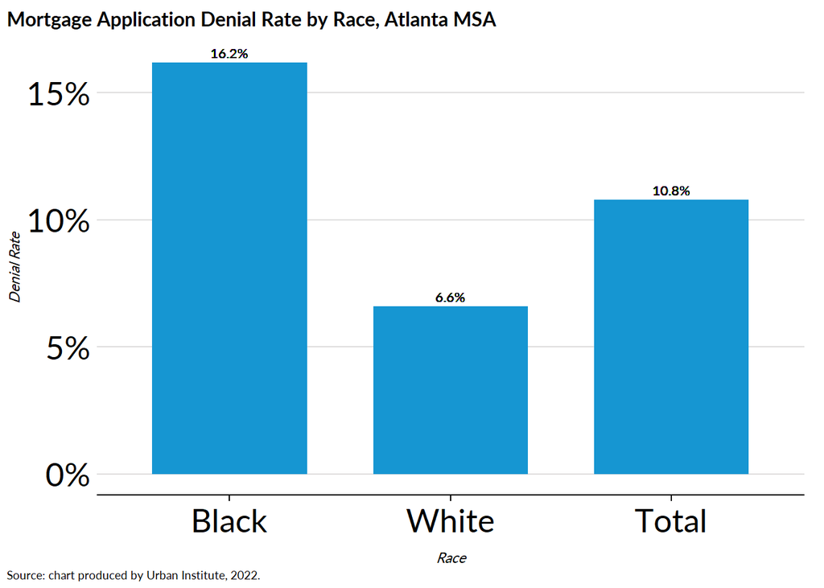

## Income

Barriers persist even when comparing among groups with similar levels of income.

### Homeownership by Race and Income, National

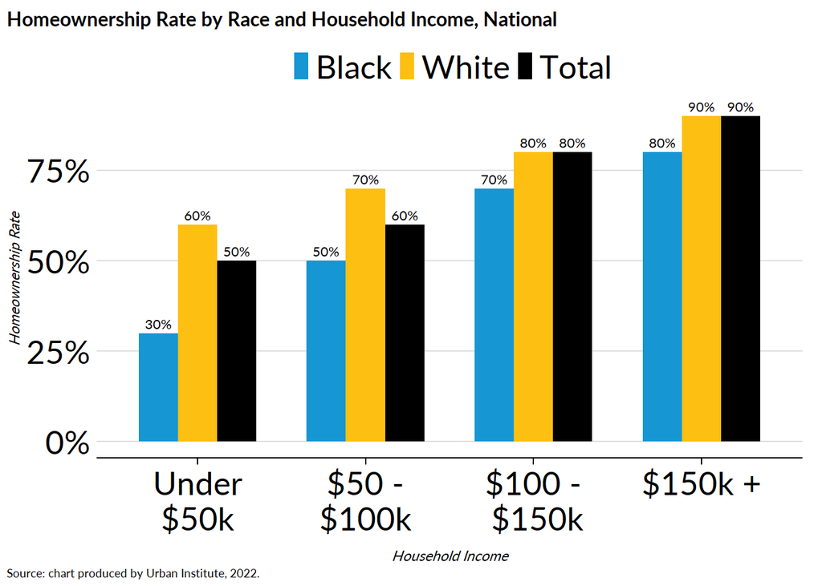

### Homeownership by Race and Income, MSA

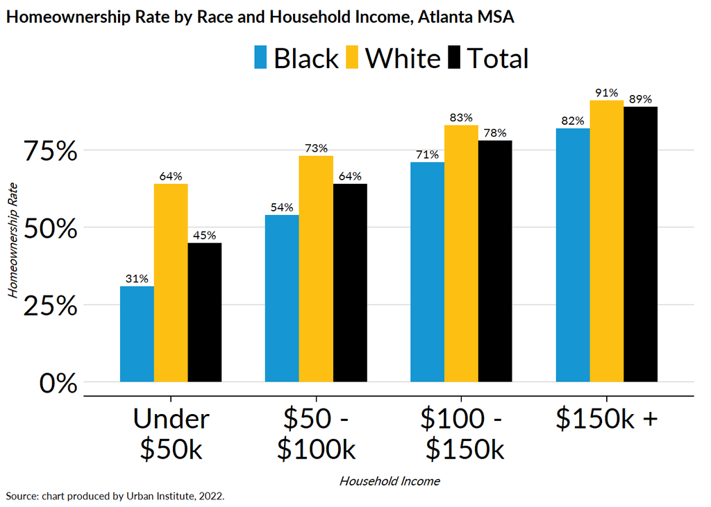

## Education

Similarly, the Black-white homeownership gap remains even when comparing among groups with similar levels of educational attainment.

### Homeownership by Race and Education, National

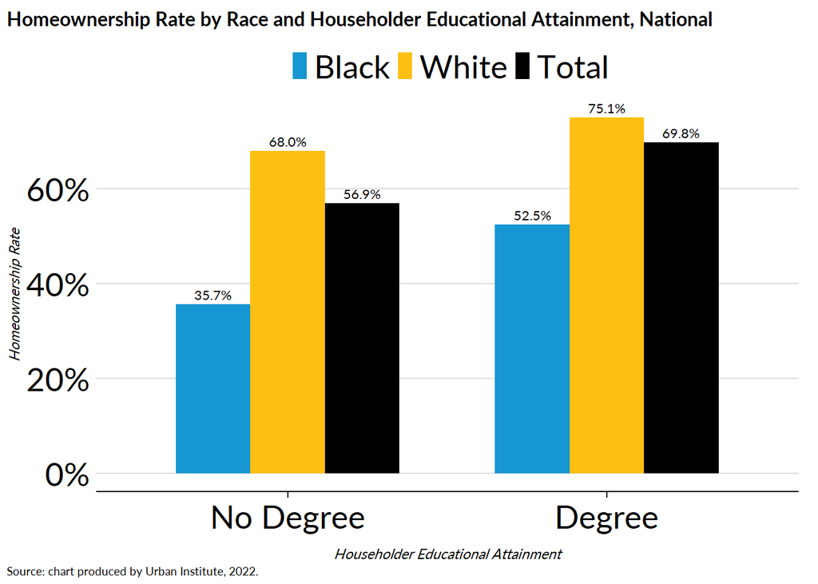

### Homeownership by Race and Education, MSA

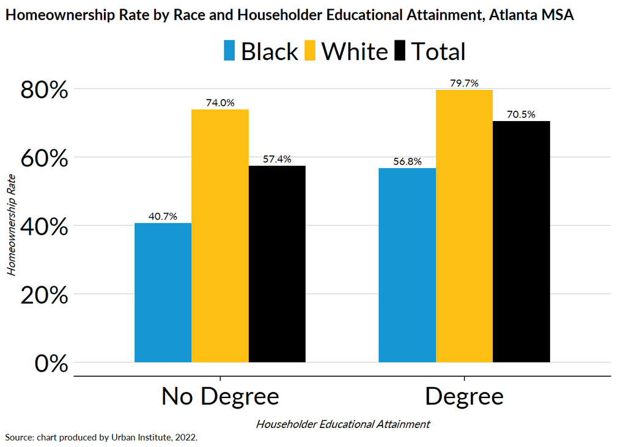